# index

# Q8: Cases vs. Deaths

As extra credit, extend your analysis in problem three to also compute the weighted mean center of daily COVID deaths.

Make two plots next to each other (using patchwork) showing cases in red and deaths in navy. Once completed describe the differences in the plots and what they mean about the spatial patterns seen with COVID impacts. (see guide on website)

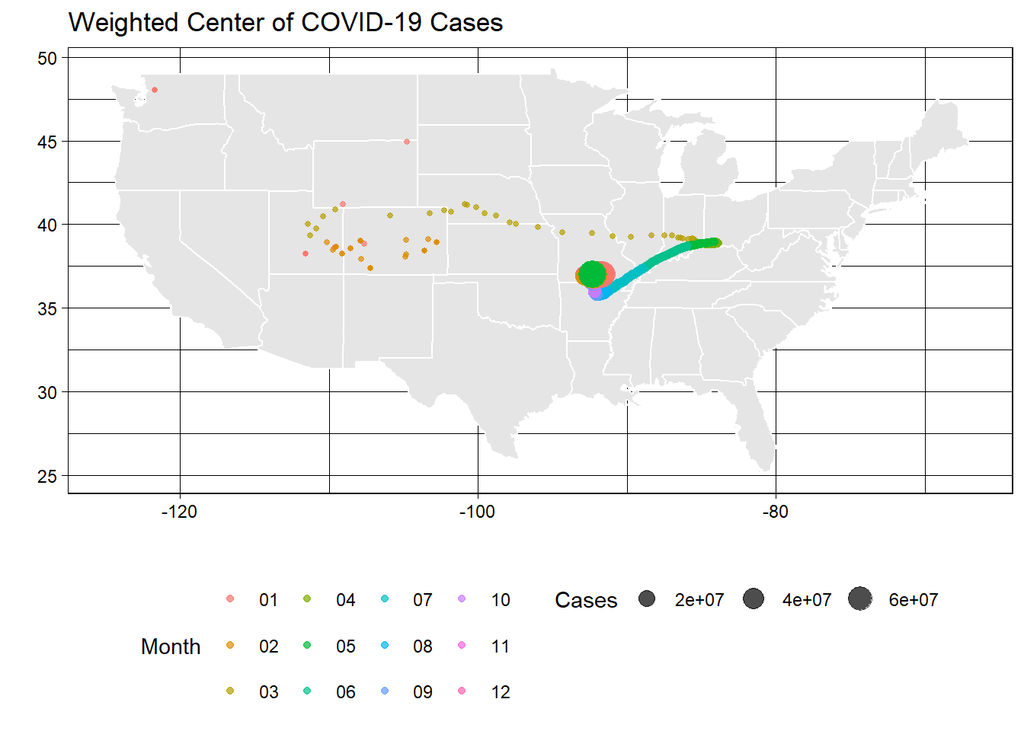

```r
# Load necessary libraries
library(ggplot2)
library(patchwork)

# Create your first plot
usa_case_map <- ggplot(meta) +
  borders("state", fill = "gray90", colour ="white") +
  geom_point(aes(x = wmX_c, y = wmY_c, size = cases, color = format(date, "%m")), alpha = 0.7) +
  theme_linedraw() +
  labs(size = "Cases", x = "", y = "", title = "Weighted Center of COVID-19 Cases", color = "Month") +
  theme(legend.position = "bottom")

# Verify if the plot object is created correctly
print(usa_case_map)  # Print the plot to the default device (screen)
```

```r
# Open the PDF device
pdf("usa_case_map.pdf", width = 10, height = 7)  # Adjust dimensions as needed

# Explicitly print the plot to the PDF device
print(usa_case_map)

# Close the PDF device
dev.off()
```

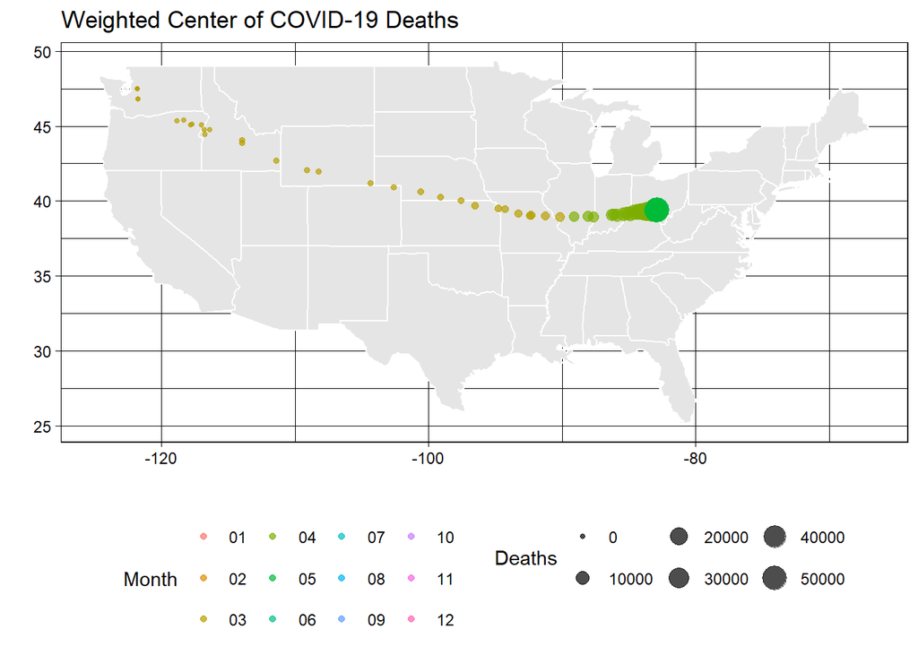

```r
meta2 <- county_centroids %>%
  inner_join(covid_pop) %>%
  group_by(date) %>%
  summarize(
    wmX_c = sum(LON*deaths / sum(deaths)),
    wmY_c = sum(LAT*deaths / sum(deaths)),
    deaths = sum(deaths)) %>%
  arrange(date) %>%
  mutate(d = 1:n())
# Create your second plot
usa_death_map <- ggplot(meta2) +
  borders("state", fill = "gray90", colour ="white") +
  geom_point(aes(x = wmX_c, y = wmY_c, size = deaths, color = format(date,"%m")), alpha = 0.7) +
  theme_linedraw() +
  labs(size = "Deaths", x = "", y = "", title = "Weighted Center of COVID-19 Deaths", color = "Month") +
  theme(legend.position = "bottom")

print(usa_death_map)
```

```r
# Open the PDF device to save the plots
pdf("usa_case_maps_patchwork.pdf", width = 5, height = 8)

# Combine the plots vertically using patchwork's | operator
usa_case_map / usa_death_map  # Use '/' to stack plots vertically
```

```r
library(htmltools)
tags$iframe(src = "C:/Users/Joshua Puyear/Documents/csu-undergrad/ess-330-joshp-2025/github/ess-330-labs/csu-ess-lab3/usa_case_maps_patchwork.pdf", width = "100%", height = "600px")
```

[interactive chart not shown]

### Q8 Response

The cases map is a much more scattered arrangement as multiple population centers were experiencing rapid rises in cases. The number of deaths is a relatively clear line from west to east. The median age of the eastern united states is slightly higher and with a greater population density (so more opportunities for cases to appear) and we know that older populations are more likely to succumb to the disease than younger people are.